```python
import numpy as np
import matplotlib.pyplot as plt
import random
```

# Week 13-14

## Quiz

1. Given an array of integers between 0 and $ n $, write a formula to calculate the number of entries in the array equal to $ k $.
2. What is a "monte carlo" simulation?
3. Write a function that takes a vote map (array of 0s and 1s) as input and returns the percentage of the population that favors party A.
4. What are the criteria for drawing congressional districts (as it pertains to our project)?

#### Answers

```python
np.sum(-1*np.ceil(np.absolute((arr - k)/n)) + 1)
```

1. The next state of the system is chosen at random from the pool of possible states.

```python
def map_lean(vote_map):
    n,m = np.shape(vote_map)
    return np.sum(vote_map)/(n*m)
```

1. - Percentage of the districts favoring party A to be close to the percentage of the population favoring party A.
   - The shape of the districts should be "centralized" and contiguous.
   - Populations (area in the case of the project) should be as equal as possible.

## Notes

```python
def make_starting_map(n,k):
    district_map = np.zeros((n,n),dtype=int)
    centers = [(random.randint(0,n-1),random.randint(0,n-1)) for _ in range(k)]
    for i,j in [(i,j) for i in range(n) for j in range(n)]:
        distances = [abs(i-a) + abs(j-b) for (a,b) in centers]
        min_dist = min(distances)
        district = distances.index(min_dist)
        district_map[i,j] = district
    return district_map
```

```python
arr = make_starting_map(100,8)
d = 8
```

```python
border_map = np.ceil((np.absolute(arr - np.roll(arr,-1,0)) + np.absolute(arr - np.roll(arr,-1,1))
 + np.absolute(arr - np.roll(arr,1,0)) + np.absolute(arr - np.roll(arr,1,1)))/(4*d))
```

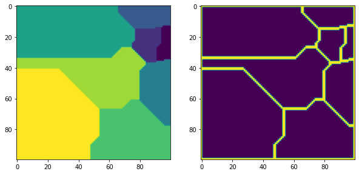

```python
plt.figure(figsize=(10,5))
plt.subplot(1,2,1)
plt.imshow(arr)
plt.subplot(1,2,2)
plt.imshow(border_map)
plt.show()
```

```python
help(np.pad)
```

[output not shown]

[output cut: 151 more lines]

[output not shown]

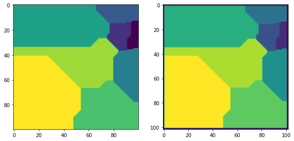

```python
padded = np.pad(arr,1,'constant',constant_values=-1)
plt.figure(figsize=(10,5))
plt.subplot(1,2,1)
plt.imshow(arr)
plt.subplot(1,2,2)
plt.imshow(padded)
plt.show()
```

```python
border_map = np.ceil((np.absolute(padded - np.roll(padded,-1,0)) + np.absolute(padded - np.roll(padded,-1,1))
 + np.absolute(padded - np.roll(padded,1,0)) + np.absolute(padded - np.roll(padded,1,1)))/(4*d))[1:101,1:101]
```

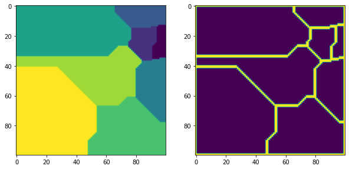

```python
plt.figure(figsize=(10,5))
plt.subplot(1,2,1)
plt.imshow(arr)
plt.subplot(1,2,2)
plt.imshow(border_map)
plt.show()
```

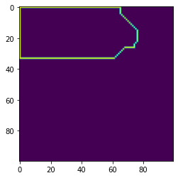

```python
num_dists = int(np.max(arr)+1)
dist = 4
dist_4 = -1*np.ceil(np.absolute(arr-dist)/num_dists)+1
plt.imshow((dist_4+border_map)//2)
plt.show()
```

```python
np.sum((dist_4+border_map)//2)
```

```
198.0
```

## Sudoku

**Exercise:** Write a function that will take a "solved" sudoku as input and check to see if it is actually solved.

**Exercise:** Write a function that will extract the sudokus from the text file containing their data.

**Exercise:** Write a function that will create a sudoku with a given percentage of blanks.

```python
A = np.ones((120,10))
set(A.flatten())
```

```
{1.0}
```